# Statistical Analysis of Housing Prices and Square Footage in King county, Washington

Duke LeTran

October 27th, 2017

# I. Introduction

This report aims to analyze the dataset “KingCounty.csv” (n = 500) which consists of randomly sampled houses in King County, Washington. Square footage of living space (X = sqft_living) is our explantory random variable, and price in dollars (Y = price) is our response random variable.

The question we are trying to answer:

```
Are we able to predict the selling price of a house based on the square footage?
```

The approach we intend to take is attempt to fit our data to the model:

```
Simple Linear Regression
```

Let’s first begin with some exploratory data analysis.

# II. Summary of Data

### Scatterplot - King County, Washington

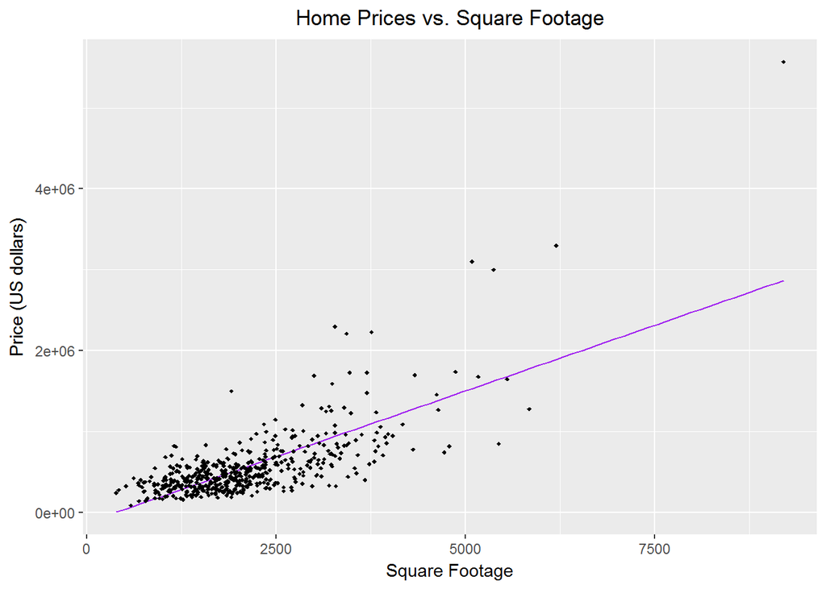

### Boxplot and Histograms - King County, Washington

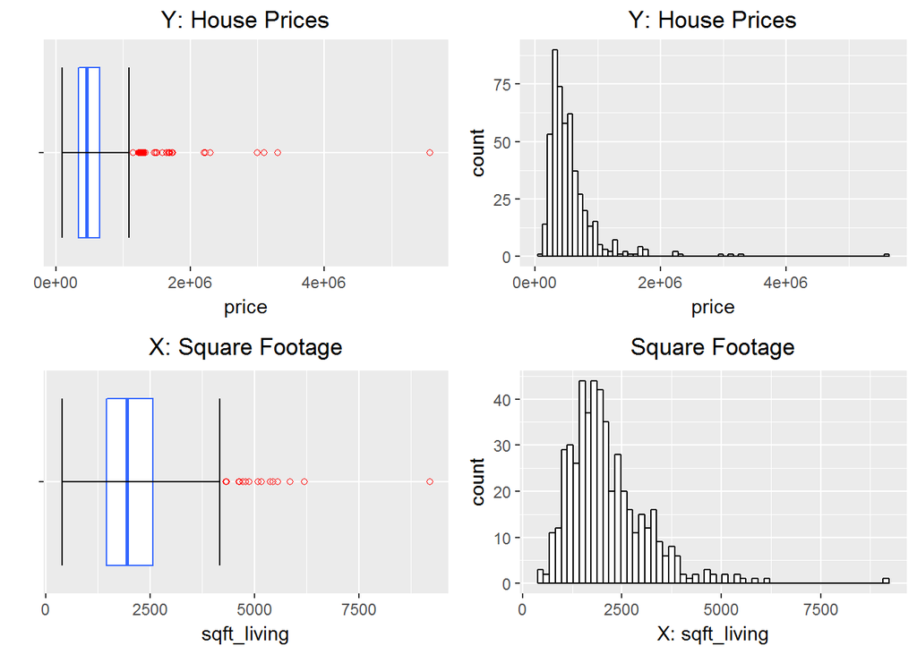

```
##      price          sqft_living
##  Min.   :  90000   Min.   : 390
##  1st Qu.: 333722   1st Qu.:1460
##  Median : 460000   Median :1940
##  Mean   : 566594   Mean   :2115
##  3rd Qu.: 646250   3rd Qu.:2562
##  Max.   :5570000   Max.   :9200
```

#### House Prices (Y)

- Sample Mean: $566,594.00
- Sample Median: $460,000.00
- Sample Standard Deviation: $434,558.60

#### Square Footage (X)

- Sample Mean: 2,115
- Sample Median: 1,940
- Sample Standard Deviation: 976.97

We see very clearly that this dataset is right-skewed for both random variables X and Y (as defined in the introduction). This is demonstrated in the boxplots by the outliers concentrated on the right and in the histograms by a right tail. This is further exemplefied by comparing the mean and the median, of which the mean is greater than the median for both random variables.

# IIIa. Diagnostics - Initial Model

Based on our raw data, this is our estimated regression line:

$Y = -120,325.50 + 324.78X$

We are 99% confident that that when our square footage (X) changes by 1 unit, the estimated change of housing prices (Y) increases between 289.5603785 and 359.9913638, on average. Since zero is not included in the confidence interval of $b_1$ and is strictly positive, a statistically significant positive relationship is suggested between housing prices(Y) and square footage(X).

Since there is a statistically significant positive relationship suggested, let’s continue to examine if our data violates any of the following assumptions:

- Homoscedasticity (constant variance)
- Normality

### ASSESSING HOMOSCEDASTICITY

#### I. Distribution of Errors

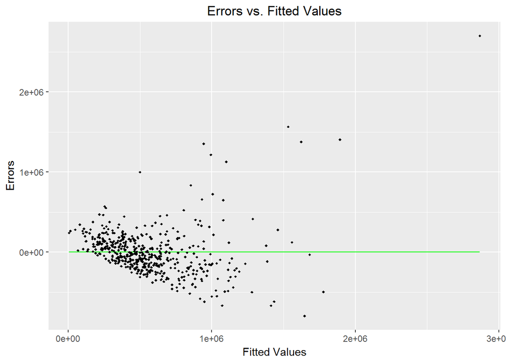

#### II. Fligner Killeen (FK) test

$H_0: \sigma_l ^2 = \sigma_u ^2$

$H_0: \sigma_l ^2 \neq \sigma_u ^2$

```
##
##  Fligner-Killeen test of homogeneity of variances
##
## data:  k$ei and k$Group
## Fligner-Killeen:med chi-squared = 21.663, df = 1, p-value =
## 3.25e-06
```

### ASSESSING NORMALITY

#### I. Histogram of $e_i$

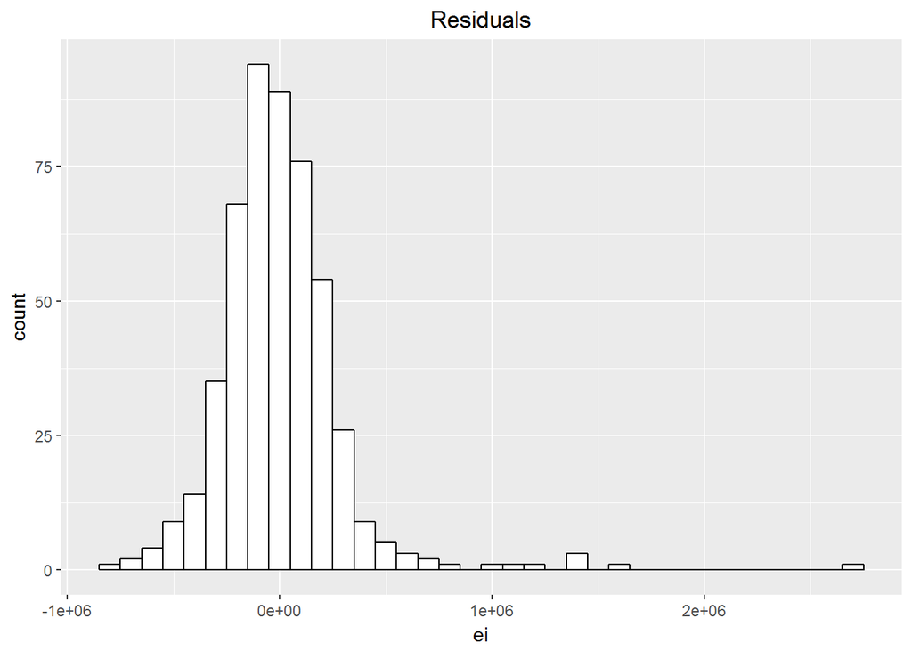

#### II. QQ Plot

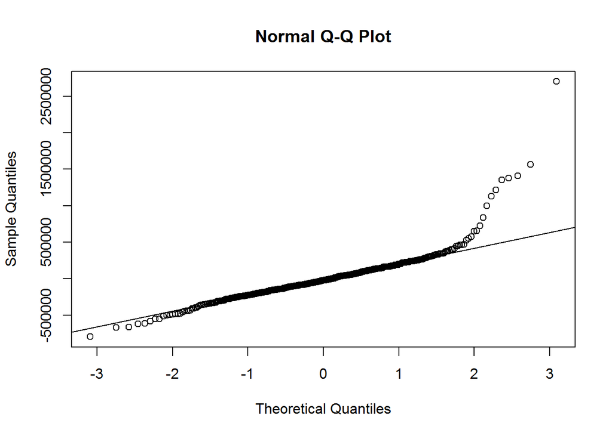

#### III. Shapiro-Wilks Test

$H_0:$ The errors are normally distributed

$H_A:$ The errors are NOT normally distributed

```
##
##  Shapiro-Wilk normality test
##
## data:  k.ei
## W = 0.82829, p-value < 2.2e-16
```

### DISCUSSION - Diagnositics

*Assessing Homoscedasticity*

The scatterplot of errors versus fitted values clearly shows an ergregious violation of constant variance – a distribution shape of a cone. Furthermore, our Fligner-Killeen test has rejected null hypothesis for all $= 0.10, 0.05, 0.1 $, which means we accept the alternative hypothesis that our variance of our lower half of the data does not equal the variance of our upper group of data.

- Scatterplot of Errors vs. Fitted Values: **FAIL**
- FK Test: **FAIL** (rejected $H_0$)

Score: 0/2

*Assessing Normality*

Our histogram of $e_i$ confirms our initial scatterplot that our data is not normal but right-skewed. Our QQPlot has most of the points very close to the QQ line but deviates towards the higher square footage. Based on the QQPlot, there is at least one significant outlier. Though it would be nice to remove the higher X datapoints, they may provide additional information (so these will not be removed). Our Shapiro-Wilks Test has rejected the null hypothesis for all $\alpha = 0.10, 0.05, 0.1$, which means that our data is non-normal – though our sample number is relatively high (n = 500), in which case the test may be conservative. Let’s proceed to remove the outlier to see if the fit of our data to the model improves.

- Histogram of $e_i$: **FAIL**
- QQPlot: **SEMI-PASS**
- SW Test: **FAIL** (rejected $H_0$)

Score: 0.5/3

# IIIb. Diagnostics - data with outliers removed

#### REMOVING OUTLIERS

```
##               Estimate Std. Error   t value     Pr(>|t|)
## (Intercept) 71582.7915 24040.1555  2.977634 3.048395e-03
## sqft_living   221.5991    10.6787 20.751511 3.826672e-69
```

$Y = 71,582.79 + 221.6X$

We are 99% confident that that when our square footage (X) changes by 1 unit, the estimated change of housing prices (Y) increases between 193.9853163 and 249.2129727, on average. Since zero is not included in the confidence interval of $b_1$ and is strictly positive, a statistically significant positive relationship is suggested between X and Y.

Since there is still a statistically significant positive relationship suggested, let’s continue to re-examine our data to see if it violates any of the following assumptions:

- Homoscedasticity (constant variance)
- Normality

### ASSESSING HOMOSCEDASTICITY

#### I. Distribution of Errors

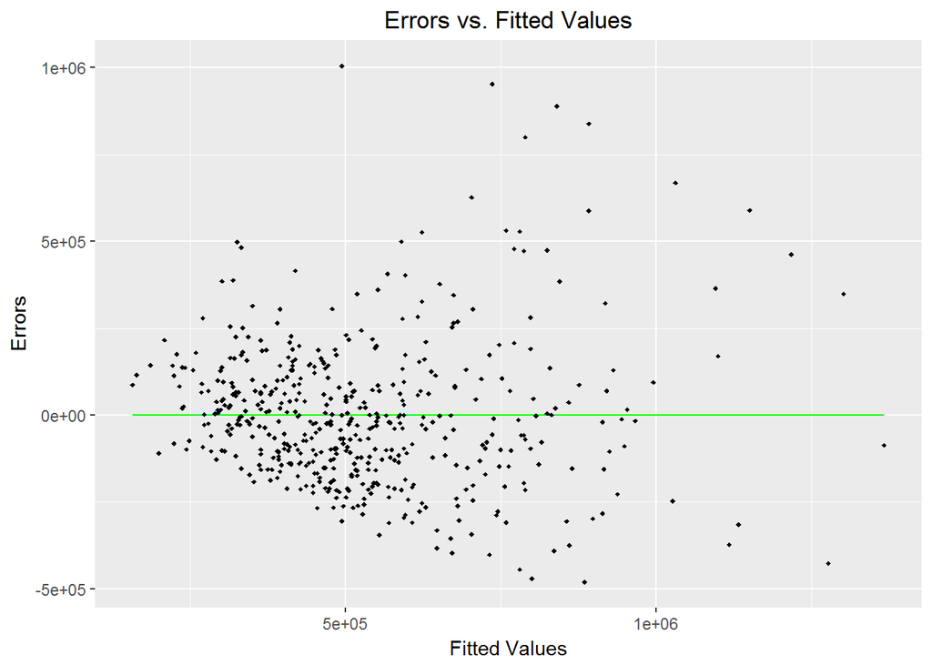

#### II. Fligner Killeen (FK) test

$H_0: \sigma_l ^2 = \sigma_u ^2$

$H_0: \sigma_l ^2 \neq \sigma_u ^2$

```
##
##  Fligner-Killeen test of homogeneity of variances
##
## data:  k2$ei and k2$Group
## Fligner-Killeen:med chi-squared = 23.866, df = 1, p-value =
## 1.033e-06
```

### ASSESSING NORMALITY

#### I. Histogram of $e_i$

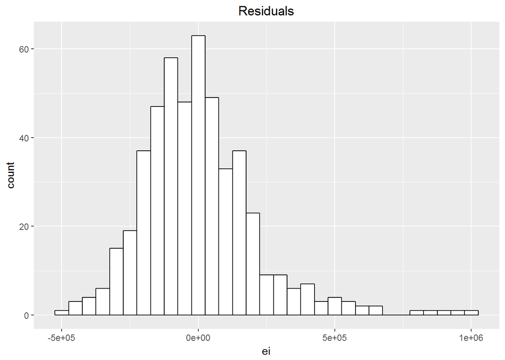

#### II. QQ Plot

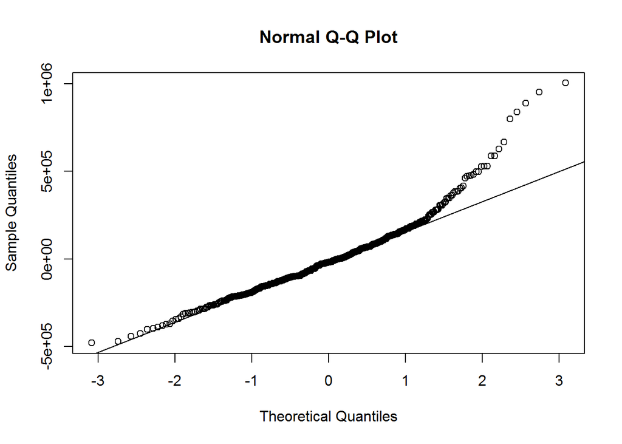

#### III. Shapiro-Wilks Test

$H_0:$ The errors are normally distributed

$H_A:$ The errors are NOT normally distributed

```
##
##  Shapiro-Wilk normality test
##
## data:  k2.ei
## W = 0.93867, p-value = 2.23e-13
```

### DISCUSSION - Diagnostics (OUTLIER REMOVED)

*Assessing Homoscedasticity*

- Errors vs. Fitted Values: **FAIL**
- FK Test: **FAIL** (rejected $H_0$)

Score: 0/2

*Assessing Normality*

Score: 1/3

# IV. Analysis

#### Overview

- Model Fit
- Significant Linear Relationship
- Diagnostics

#### I. Model Fit

```
## Analysis of Variance Table
##
## Response: price
##              Df     Sum Sq    Mean Sq F value    Pr(>F)
## sqft_living   1 1.8819e+13 1.8819e+13  430.63 < 2.2e-16 ***
## Residuals   491 2.1457e+13 4.3701e+10
## ---
## Signif. codes:  0 '***' 0.001 '**' 0.01 '*' 0.05 '.' 0.1 ' ' 1
```

Our cooefficient of determination $R^2$ is $46.72$%.

Thus, $46.72$% of the variance in housing prices (Y) is explained by the linear relationship with square footage (X).

#### II. Significant linear Relationship

**Estimated Regression Line**

Our estimated regression line is:

$Y = 71,582.79 + 221.6X$

**Hypothesis Testing of $b_1$**

Our alternative hypothesis states ($H_A$) that there is a significant positive relationship between housing prices (Y) and square footage (X), which is equivalent to $H_A > 0$.

Thus, we reject the null hypothesis and accept the alternative hypothesis that there is a significant positive linear relationship.

**Confidence interval of $b_1$**

Our confidence interval for $b_1$:

```
##    0.5 %   99.5 %
## 193.9853 249.2130
```

We are 99% confident that when square footage(X) increases by 1 unit, housing prices (Y) increases between 193.9853 and 249.2130, on average. Since our confidence interval does not contain zero and is strictly positive, it suggests a statistically significant positive linear relationship, on average.

#### III. Diagnostics

A summary is provided below:

*Assessing Homoscedasticity*

- Scatterplot of Errors vs. Fitted Values: **FAIL**
- FK Test: **FAIL** (rejected $H_0$)

Score: 0/2

*Assessing Normality*

Score: 1/3

# V. Interpretation

Our sample data (n = 500) of the houses in King County, Washington suggests that there is a statistically significant positive linear relationship between housing prices(Y) and square footage. Furthermore, we are 99% confident that when square footage(X) increases by 1 unit, housing prices (Y) increases between 193.9853 and 249.2130, on average.

However, based on the diagnostic tests assessing homoscedasticity and normality, our simple linear regression model has commited ergregious violations of our underlying assumptions.

The author of this paper highly recommends caution when using this model with the intent of accurately predicting housing prices based on square footage.

# VI. Prediction Results

As stated in the Interpretation section, the author of this paper highly recommends caution when using this model with the intent of accurately predicting housing prices based on square footage. However, we will proceed to make the following prediction anyways…

We will restate the estimated regression line here for reference:

$Y = 71,582.79 + 221.6X$

#### Task 1 by client: Predict the average house price for houses with living square footage 2800.

Our predicted average house price for houses with living square footage 2800 is $692,060.40

We are 99% confident that, on average, houses with a living square footage of 2800 will sell in between the interval of $660,476.80 and $723,644.00

#### Task 2 by client: Predict the price of a particular house with living square footage 3200.

Our predicted average house price for a single house with living square footage 3200 is $780,700.10

We are 99% confident that, on average, a house with a living square footage of 3200 will sell in between the interval of $238,685.50 and $1,322,715.00

#### Task 3 by client: Predict the average house price for houses with living square footage 8000.

Our predicted average house price for houses with living square footage 8000 is $1,844,376.00

We are 99% confident that, on average, houses with a living square footage of 8000 will sell in between the interval of $1,678,864.00 and $2,009,888.00

# VII. Conclusions

Based on our hypothesis testing and confidence interval, we see that there is a significant positive linear relationship between housing prices (Y) and square footage (X) of the homes in King County, Washington.

From the original scatterplots, histograms, and boxplots, our inference that the data is right-skewed is confirmed by further assessing the QQplots, histogram of errors, and scatterplot of errors versus fitted values. This perhaps may be a suggestion that our model is more reliable under some unidentified value of square footage.

Please carefully consider these stated concerns when utilizing the predicted values of housing prices for the specified square footage.

### R Appendix Of Code

```r
# Initialize - Read, Library
k <- read.csv("C:/Users/dletran/Dropbox/Documents/108 - STA, linear regression/Projects/project1/KingCounty.csv")
library(ggplot2)
library(gridExtra)

###### I. Introduction
n = nrow(k)
k_col = names(k)

###### II. Summary of Data
# Scatterplots
ggplot(k, aes(x = sqft_living, y = price)) +
  geom_smooth(method='lm', se = FALSE, color = "purple", size = 0.4) +
  geom_point(size=1, shape=18) +
  ggtitle("Home Prices vs. Square Footage") +
  theme(plot.title = element_text(hjust = 0.5)) +
  ylab("Price (US dollars)") +
  xlab("Square Footage")
# Boxplots
b_sqft <- ggplot(k,
       aes(y = sqft_living, x = factor(""))) +
  geom_boxplot(fill = "white", colour = "#3366FF", outlier.color = "red", outlier.shape = 1) +
  ylab("sqft_living") +
  xlab(" ") +
  coord_flip() + #flips it from vertical to sideways plots
  ggtitle("X: Square Footage") +
  theme(plot.title = element_text(hjust = 0.5)) +#centers the title
  stat_boxplot(geom ='errorbar')
b_price <- ggplot(k,
       aes(y = price, x = factor(""))) +
  geom_boxplot(fill = "white", colour = "#3366FF", outlier.color = "red", outlier.shape = 1) +
  ylab("price") +
  xlab(" ") +
  coord_flip() + #flips it from vertical to sideways plots
  ggtitle("Y: House Prices") +
  theme(plot.title = element_text(hjust = 0.5)) +#centers the title
  stat_boxplot(geom ='errorbar')
# Histograms
h_price <- ggplot(k,
       aes(x = price)) +
  geom_histogram(binwidth = 80000, color = "black",fill = "white") +
  xlab("price") +
  ggtitle("Y: House Prices") +
  theme(plot.title = element_text(hjust = 0.5))
h_sqft <- ggplot(k,
       aes(x = sqft_living)) +
  geom_histogram(binwidth = 150, color = "black",fill = "white") +
  xlab("X: sqft_living") +
  ggtitle("Square Footage") +
  theme(plot.title = element_text(hjust = 0.5))
# mutiplot
grid.arrange(b_price, h_price, b_sqft, h_sqft, ncol=2)
# Summary of Data
summary(k)
k_var_price = var(k$price)
k_var_sqft = var(k$sqft_living)
k_std_price = sd(k$price)
k_std_sqft = sd(k$sqft_living)

###### IIIa. Diagnostics - Initial Model
#simple linear model
k_model = lm(price ~ sqft_living, data=k)
#initialize for diagnostics
k.sum = summary(k_model)
k.HT = k.sum$coefficients
k.b1 = round(k.HT[2,1], 2)
k.b0 = round(k.HT[1,1], 2)
k.sb1 = round(k.HT[2,2], 2)
k$ei = k_model$residuals
k$yhat = k_model$fitted.values
#quick check to see if there a significant linear relationship for b1
####confidence intervals
k.CI = confint(k_model, level = 0.99)
k.CI.b1 = k.CI[2,]
##ASSESSING HOMOSCEDASITICITY
#i.Distribution of Errors
ggplot(k,
       aes(x = yhat, y = ei)) +
  geom_smooth(method='lm', se = FALSE, color = "green", size = 0.4) +
  geom_point(size=1, shape=18) +
  ggtitle("Errors vs. Fitted Values") +
  theme(plot.title = element_text(hjust = 0.5)) +
  ylab("Errors") +
  xlab("Fitted Values")
#ii.Fligner Killeen Test
Group = rep("Lower",nrow(k))
Group[k$price > median(k$price)] = "Upper"
Group = as.factor(Group)
k$Group = Group
k.FKtest = fligner.test(k$ei, k$Group)
k.FKtest
##ASSESSING NORMALITY
#i.histogram of ei
ggplot(k,
       aes(x = ei)) +
  geom_histogram(binwidth = 100000, color = "black",fill = "white") +
  xlab("ei") +
  ggtitle("Residuals") +
  theme(plot.title = element_text(hjust = 0.5))
#ii. qqplot
qqnorm(k_model$residuals)
qqline(k_model$residuals)
#iii. shapiro-wilks test
k.ei = k_model$residuals
k.SWtest = shapiro.test(k.ei)
k.SWtest

###### IIIb.Diagnostics - data with outliers removed
#Removing Outliers
cutoff = 2.0 *10^6
outliers1 = which(k$price > cutoff | k$price < -cutoff)
k2 = k[-outliers1,]
#simple linear model - 2nd iteration (k2)
k_model = lm(price ~ sqft_living, data=k2)
#initialize for diagnostics
k2.sum = summary(k_model)
k2.HT = k2.sum$coefficients
k2.HT
k2.b1 = round(k2.HT[2,1], 2)
k2.b0 = round(k2.HT[1,1], 2)
k2.sb1 = round(k2.HT[2,2], 2)
k2.b1.t = round(k2.HT[2,3]/2, 2) #divide by 2 for one-tail test
k2.b1.p = k2.HT[2,4]
k2$ei = k_model$residuals
k2$yhat = k_model$fitted.values
#quick check to see if there a significant linear relationship for b1
#confidence intervals
k2.CI = confint(k_model, level = 0.99)
k2.CI.b1 = k2.CI[2,]
##ASSESSING HOMOSCEDASTICITY
#i. distribution of errors
ggplot(k2,
       aes(x = yhat, y = ei)) +
  geom_smooth(method='lm', se = FALSE, color = "green", size = 0.4) +
  geom_point(size=1, shape=18) +
  ggtitle("Errors vs. Fitted Values") +
  theme(plot.title = element_text(hjust = 0.5)) +
  ylab("Errors") +
  xlab("Fitted Values")
#ii.fligner killeen test
Group = rep("Lower",nrow(k2))
Group[k2$price > median(k2$price)] = "Upper"
Group = as.factor(Group)
k2$Group = Group
k2.FKtest = fligner.test(k2$ei, k2$Group)
k2.FKtest
##ASSESSSING NORMALITY
#i.histogram of ei
ggplot(k2,
       aes(x = ei)) +
  geom_histogram(binwidth = 50000, color = "black",fill = "white") +
  xlab("ei") +
  ggtitle("Residuals") +
  theme(plot.title = element_text(hjust = 0.5))
#ii. qqplot
qqnorm(k_model$residuals)
qqline(k_model$residuals)
#iii. shapiro-wilks test
k2.ei = k_model$residuals
k2.SWtest = shapiro.test(k2.ei)
k2.SWtest

##### IV. Analysis
#i.Model Fit
k_table = anova(k_model)
k_table
SSE = k_table[2,2]
SSR = k_table[1,2]
SSTO = SSE + SSR
R2 = round(SSR/SSTO * 100, 2)
#confidence interval for b1
k2.CI.b1

#V. Interpretation
#No code was used in interpretation

##### VI. Prediction Results - Initialize
xs.1 = data.frame(sqft_living = 2800)
xs.2 = data.frame(sqft_living = 3200)
xs.3 = data.frame(sqft_living = 8000)
#Task 1 by client
ys.1.CI = predict(k_model, xs.1, interval = "confidence", level = 0.99)
#Task 2 by client
ys.2.PI = predict(k_model, xs.2, interval = "prediction", level = 0.99)
#Task 3 by client
ys.3.CI = predict(k_model, xs.3, interval = "confidence", level = 0.99)

##### VII. Conclusions
#No code was used in the conclusions
```